# Principes et M?thodes Statistiques

# Fiche 1 - Exercice 1

Soit $X$ une variable al?atoire de loi normale ${\cal N}(m,\sigma^2)$, $m \in R, \sigma \in R^{+*}$. $X$ est ? valeurs dans $R$, son esp?rance est $E[X]=m$ et sa variance est $Var[X]=\sigma^2$.

La densit? de la loi ${\cal N}(m,\sigma^2)$ est :
$$f_X(x) = {\displaystyle \frac{1}{\sigma \sqrt{2\pi}}} \, e^{ - \frac{(x - m)^2}{2\sigma^2}}$$

Sa fonction de r?partition n’a pas d’expression explicite :
$$F_X(x) = \int_{-\infty}^x f_X(u) du = \int_{-\infty}^x {\displaystyle \frac{1}{\sigma \sqrt{2\pi}}} \, e^{- \frac{(u - m)^2}{2\sigma^2}} du$$

## Question 1

Tracer les densit?s des lois ${\cal N}(2,1)$, ${\cal N}(-3,1)$ et ${\cal N}(-3,9)$.

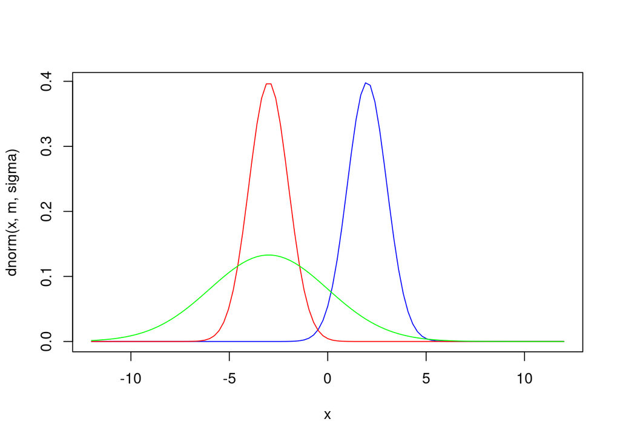

```r
m<-2
sigma<-1
curve(dnorm(x,m,sigma),-12,12, col="blue")

m<--3
curve(dnorm(x,m,sigma),add=T, col="red")

sigma<-3
curve(dnorm(x,m,sigma),add=T, col="green")
```

On remarque que l’aire sous la densit? est constante (elle vaut 1).

## Question 2

Tracer les fonctions de r?partition de ces m?mes lois. Calculer $P(X \leq 0)$ dans les 3 cas.

```r
m<-2
sigma<-1
curve(pnorm(x,m,sigma),-12,12, col="blue")
pnorm(0,m,sigma)
```

```
## [1] 0.02275013
```

```r
m<--3
curve(pnorm(x,m,sigma),add=T, col="red")
pnorm(0,m,sigma)
```

```
## [1] 0.9986501
```

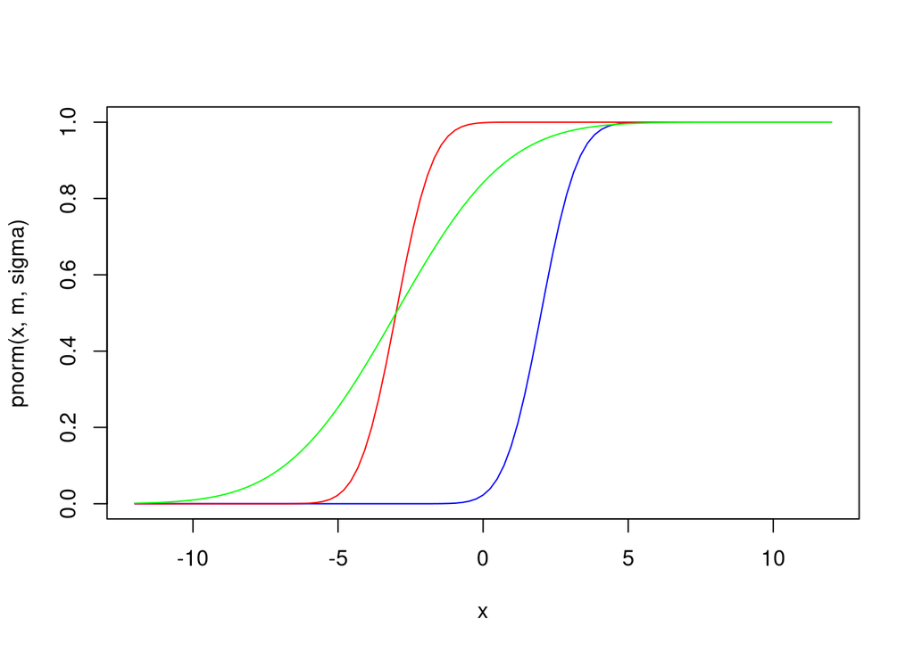

```r
sigma<-3
curve(pnorm(x,m,sigma),add=T, col="green")
```

```r
pnorm(0,m,sigma)
```

```
## [1] 0.8413447
```

## Question 3

Soit $U$ une variable al?atoire de loi normale centr?e-r?duite ${\cal N}(0,1)$. Tracer la densit? de $U$. On note $\phi$ sa fonction de r?partition.

Calculer $P(U \leq 0)$, $P(U \leq 1.25)$, $P(U \leq 1)$ et $P(U \leq -1)$. Retrouver ces r?sultats ? l’aide de la table 1 de la loi normale centr?e-r?duite en 8.2.1.

```r
m<-0
sigma<-1
curve(dnorm(x,m,sigma),-4,4)
abline(h=0)

pnorm(0)
```

```
## [1] 0.5
```

```r
lines(c(0,0),c(0,dnorm(0)),col="red",lwd=2)

pnorm(1.25)
```

```
## [1] 0.8943502
```

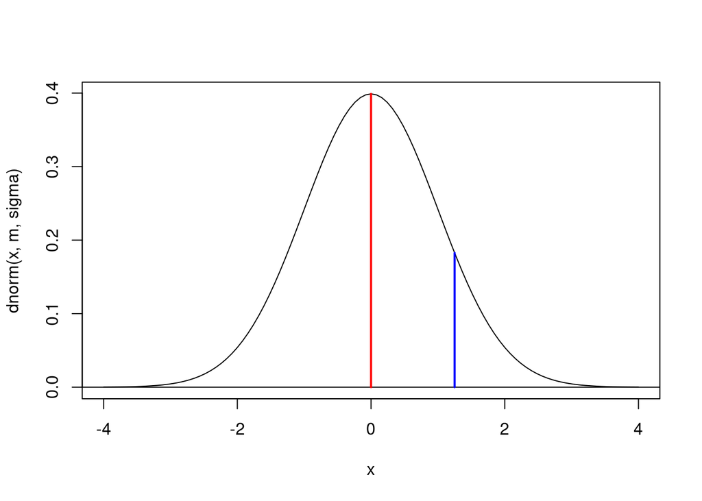

```r
lines(c(1.25,1.25),c(0,dnorm(1.25)),col="blue",lwd=2)
```

```r
pnorm(1)
```

```
## [1] 0.8413447
```

```r
1-pnorm(1)
```

```
## [1] 0.1586553
```

```r
pnorm(-1)
```

```
## [1] 0.1586553
```

## Question 4

Calculer $u_{0.05} = \phi^{-1}(1-0.05/2)$ et $u_{0.25} = \phi^{-1}(1-0.25/2)$. Retrouver ces r?sultats ? l’aide de la la table 2 de la loi normale centr?e-r?duite en 8.2.2.

```r
qnorm(1-0.05/2)
```

```
## [1] 1.959964
```

```r
qnorm(1-0.25/2)
```

```
## [1] 1.150349
```

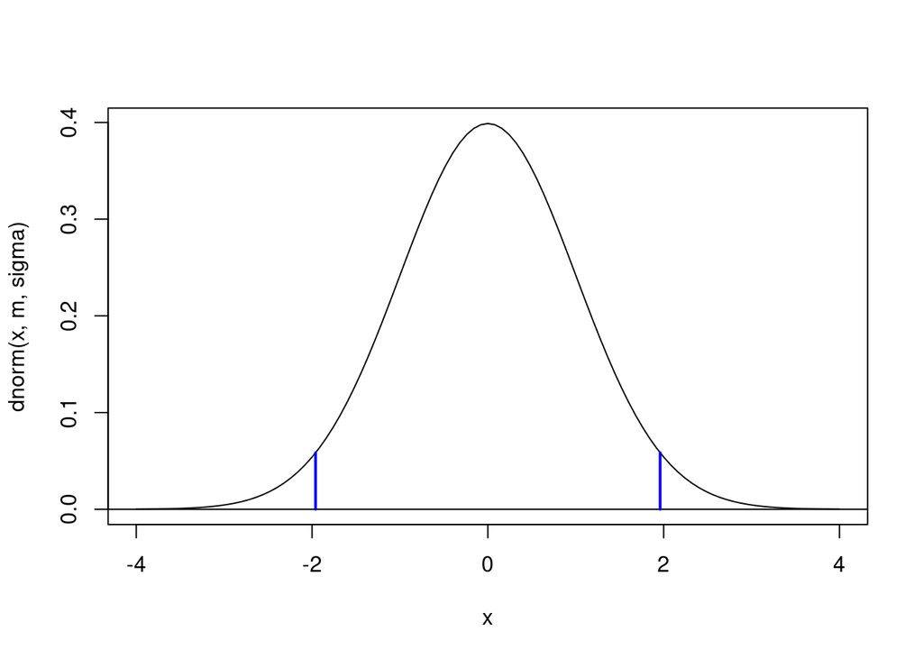

```r
curve(dnorm(x,m,sigma),-4,4)
abline(h=0)
lines(c(qnorm(1-0.05/2),qnorm(1-0.05/2)),c(0,dnorm(qnorm(1-0.05/2))),col="blue",lwd=2)
lines(c(-qnorm(1-0.05/2),-qnorm(1-0.05/2)),c(0,dnorm(qnorm(1-0.05/2))),col="blue",lwd=2)
```